# BugHub

## Create Knowledge Graph (Networkx)

### for GitHub Topics/Repos/Issues and StackOverflow Tags/Questions/Answers

### Deliverables:

- Submit a single ZIP file that has the folowing items:
  1. Your IPYNB script that has your source code and output for the requirements listed
  2. Your Panoptio Video demo of live run

## Requirement 1

# Add your code for this requirement in this cell

1. List all objects, properties and links that are needed to represent the graph data model

of the knowledge graph of GitHub topics, tags, repositories, and issues.

**Objects:**

git: a distributed version control system used for managing software development projects.  
GitHub: a web-based hosting service for version control using git.  
Repository: a location where code is stored and managed.  
Project: a tool for organizing and prioritizing work on a GitHub repository.  
Wiki: a collaborative tool for creating and sharing documentation for a repository.  
Pulse: a visualization of activity for a repository, including issues, pull requests, and code commits.  
Graph: a visualization of the commit history for a repository.  
Code: the source code files in a repository.  
Issue: a problem or feature request that has been identified in a repository.  
Commit: a change to the code that has been made and saved in the repository's history.  
Branch: a parallel version of the code that allows for independent development and testing.  
Clone: a copy of a repository that can be worked on locally.  
Remote: a version of a repository hosted on a remote server.  
Fork: a copy of a repository that can be modified independently of the original.  
Pull: a request to merge changes from one branch or repository to another.  
Log: a history of all commits made to a repository.  
Merge: combining two or more branches or repositories into one.  
Push: uploading local changes to a remote repository.  
Tag: a label assigned to a specific commit to mark it as significant.  
Release: a version of the code that is considered stable and ready for production use.  
History: a record of all changes made to a repository.  
File: a single unit of code or documentation in a repository.  
General Comment : A general comment is a comment that is not associated with any specific line or file in a repository. It can be used to provide feedback, ask questions, or share information about the project.  
Line Comment: A line comment is a comment that is associated with a specific line of code in a file. It can be used to provide feedback, suggest changes, or ask questions about a specific piece of code.  
Review - A review is a process for providing feedback on a pull request or other code change. GitHub provides tools for conducting code reviews, including commenting, approving or rejecting changes, and marking items as resolved.  
User Account: A user account is a personal account that is used to manage and contribute to GitHub repositories. User accounts can be associated with a public profile, and can be used to manage personal repositories or contribute to other projects.  
Organization Account: An organization account is a special type of account that is used to manage repositories and collaborate on projects with other users. Organization accounts can be used to manage team memberships, access control, and other administrative tasks.  
README.md: A README.md file is a special file in a repository that provides documentation and instructions for using the project. It is often the first file that users see when visiting a repository, and can be used to provide context and guidance for the project.  
CONTRIBUTING.md: A CONTRIBUTING.md file is a special file in a repository that provides guidelines and instructions for contributing to the project. It can include information about coding standards, issue reporting, and other aspects of the development process.  
ISSUE_TEMPLATE.md: An ISSUE_TEMPLATE.md file is a special file in a repository that provides a template for creating new issues. It can be used to standardize the issue reporting process and ensure that all necessary information is included in each issue.  
System Configuration: System configuration refers to the configuration of the underlying infrastructure that powers GitHub, including servers, databases, and other systems.  
Global Configuration: Global configuration refers to the configuration of GitHub as a platform, including settings for security, access control, and other platform-wide settings.  
Local Configuration: Local configuration refers to the configuration of a specific repository or development environment, including settings for version control, code review.

**Links:**

**GitHub to Repository**  
A GitHub can have many repositories.  
**Repository to Project**  
A repository can be part of many projects.  
**Project to Repository**  
A project can have many repositories.  
**Repository to Wiki**  
A repository can have a wiki.  
**Repository to Pulse**  
A repository can have a pulse.  
**Repository to Graph**  
A repository can have a graph.  
**Repository to Code**  
A repository can have code.  
**Repository to Issue**  
A repository can have issues.  
**Issue to Repository**  
An issue belongs to a repository.  
**Commit to Repository**  
A commit belongs to a repository.

**Properties:**  
**GitHub**  
name  
description  
url  
created_at  
updated_at  
archived  
visibility  
**Repository**  
name  
description  
url  
created_at  
updated_at  
archived  
visibility  
owner  
collaborators  
languages  
stars  
forks  
issues  
pull_requests  
commits  
branches  
tags  
releases  
**Project**  
name  
description  
url  
created_at  
updated_at  
archived  
visibility  
repositories  
issues  
pull_requests  
commits  
branches  
tags  
releases  
**Wiki**  
name  
description  
url  
created_at  
updated_at  
archived  
visibility  
pages  
**Pulse**  
name  
description  
url  
created_at  
updated_at  
archived  
visibility  
notifications  
activity  
**Graph**  
name  
description  
url  
created_at  
updated_at  
archived  
visibility  
nodes  
edges  
**Code**  
name  
description  
url  
created_at  
updated_at  
archived  
visibility  
files  
comments  
reviews  
**Issue**  
title  
body  
created_at  
updated_at  
closed_at  
assignee  
labels  
milestone  
state  
comments  
reviews  
**Commit**  
hash  
message  
author  
date  
changes  
**Branch**  
name  
upstream  
merged_into  
commits  
HEAD  
**Tag**  
name  
message  
commit  
releases  
**Release**  
name  
tag  
description  
date  
assets  
**File**  
name  
path  
content  
type  
size  
encoding  
comments  
reviews  
**General Comment**  
author  
date  
content  
**Line Comment**  
line_number  
author  
date  
content  
**Review**  
author  
date  
content  
**User Account**  
name  
email  
created_at  
updated_at  
archived  
visibility  
repositories  
issues  
pull_requests  
commits  
branches  
tags  
releases  
**Organization Account**  
name  
email  
created_at  
updated_at  
archived  
visibility  
repositories  
issues  
pull_requests  
commits  
branches  
tags  
releases  
**README.md**  
content  
**CONTRIBUTING.md**  
content  
**ISSUE_TEMPLATE.md**  
content  
**System Configuration**  
name  
value  
**Global Configuration**  
name  
value  
**Local Configuration**  
name  
value

### Requirement 2:

```python
#Add your code for this requirement in this cell
### List all objects, properties and links that
###are needed to represent the graph data model of the knowledge graph of StackOverflow tags, questions, and answers.


Object: User
Properties: user_id, display_name, reputation, profile_image_url
Links: asks, answers, follows, edits

Object: Tag
Properties: tag_id, tag_name, description
Links: applied_to, belongs_to, part_of

Object: Question
Properties: question_id, title, body, score, creation_date, view_count, accepted_answer_id
Links: asked_by, tagged_with, has_answer, duplicates, related

Object: Answer
Properties: answer_id, body, score, creation_date, is_accepted
Links: answered_to, commented_on

Object: Comment
Properties: comment_id, body, score, creation_date
Links: commented_on, replied_to

Object: Vote
Properties: vote_id, vote_type, creation_date
Links: voted_on

Object: Badge
Properties: badge_id, badge_name, badge_type, description, creation_date
Links: awarded_to, earns

Object: Review
Properties: review_id, review_type, creation_date, approval_status
Links: reviewed, suggested_edits

Object: Flag
Properties: flag_id, flag_type, creation_date, status
Links: flagged, flagged_by

Object: Close Vote
Properties: vote_id, vote_type, creation_date, status
Links: closed, closed_by, marked_as_duplicate

These objects, properties, and links can be used to represent various aspects of StackOverflow such as
users, tags, questions, answers, comments, votes, badges, reviews, flags, and close votes.

Links in more detail :
    A question is tagged with one or more tags.
    An answer is associated with a question it is answering.
    A user can ask many questions and provide many answers.
    A question can have multiple answers.
    A question can be marked as a duplicate of another question.
    A question can be upvoted or downvoted by multiple users.
    An answer can be upvoted or downvoted by multiple users.
    A user can follow a tag and receive updates on related questions.
    A user can flag a question or answer for moderation.
    A question or answer can be edited by multiple users.
```

```python
#installations
#!pip install networkx
#!pip install matplotlib
```

```python
#imports
import pandas as pd
import numpy as np
import matplotlib.pyplot as plt
import networkx as nx
```

### Requirement 3:

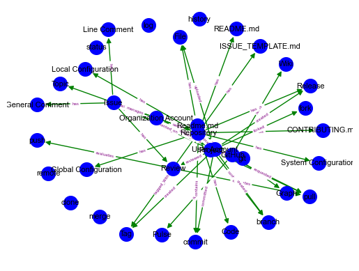

```
Nodes of Github graph:
['git', 'GitHub', 'Repository', 'Project', 'Wiki', 'Pulse', 'Graph', 'Code', 'Issue', 'commit', 'branch', 'clone', 'remote', 'fork', 'pull', 'log', 'merge', 'push', 'status', 'Tag', 'Release', 'history', 'File', 'General Comment', 'Line Comment', 'Review', 'User Account', 'Organization Account', 'RE…

Edges of Github graph:
[('git', 'GitHub'), ('GitHub', 'Repository'), ('GitHub', 'Project'), ('GitHub', 'Wiki'), ('GitHub', 'Pulse'), ('GitHub', 'Graph'), ('Repository', 'Code'), ('Repository', 'Issue'), ('Repository', 'commit'), ('Repository', 'branch'), ('Repository', 'Tag'), ('Repository', 'Release'), ('Repository', 'Fi…


Output all the properties and links of the nodes and edges in the graph:


Repository node properties: ['name', 'description', 'language', 'created_at', 'updated_at']
Issue node properties: ['title', 'description', 'created_at', 'updated_at']
commit node properties: ['message', 'created_at']
pull node properties: ['title', 'description', 'created_at', 'updated_at']
Tag node properties: ['created_at']
User Account node properties: ['username', 'email', 'location', 'website']
Organization Account node properties: ['name', 'description', 'location', 'website']
Topic node properties: ['name']



git to GitHub edge link: owns
GitHub to Repository edge link: owns
GitHub to Project edge link: owns
GitHub to Wiki edge link: owns
GitHub to Pulse edge link: owns
GitHub to Graph edge link: owns
Repository to Code edge link: has
Repository to Issue edge link: has
Repository to commit edge link: contains
Repository to branch edge link: contains
Repository to Tag edge link: tagged_With
Repository to Release edge link: has
Repository to File edge link: has
Repository to README.md edge link: has
Repository to CONTRIBUTING.md edge link: has
Repository to ISSUE_TEMPLATE.md edge link: has
Repository to System Configuration edge link: has
Repository to Global Configuration edge link: has
Repository to Local Configuration edge link: has
Repository to Topic edge link: related_to
Project to Issue edge link: includes
Project to pull edge link: includes
Issue to General Comment edge link: has
Issue to Line Comment edge link: has
Issue to Review edge link: has
Review to pull edge link: evaluates
Review to push edge link: evaluates
User Account to Repository edge link: collaborates_on
User Account to Organization Account edge link: member_of
User Account to commit edge link: committed
User Account to pull edge link: requested
User Account to Issue edge link: commented_on
User Account to Review edge link: reviewed
User Account to File edge link: uploaded
User Account to fork edge link: forked
User Account to branch edge link: created
User Account to Tag edge link: created
User Account to Release edge link: created
Organization Account to Repository edge link: owns
Organization Account to Issue edge link: manages
Readme.md to Repository edge link: contains info
```

```python
#Add your code for this requirement in this cell
### Use networkx package to create the graph data model of the knowledge graph (Network) for GitHub
import networkx as nx

# create an empty mgraph
github_graph = nx.DiGraph()

# add nodes to the graph
github_graph.add_nodes_from([
    'git', 'GitHub', 'Repository', 'Project', 'Wiki', 'Pulse', 'Graph',
    'Code', 'Issue', 'commit', 'branch', 'clone', 'remote', 'fork', 'pull',
    'log', 'merge', 'push', 'status', 'Tag', 'Release', 'history', 'File',
    'General Comment', 'Line Comment', 'Review', 'User Account',
    'Organization Account', 'README.md', 'CONTRIBUTING.md',
    'ISSUE_TEMPLATE.md', 'System Configuration', 'Global Configuration',
    'Local Configuration'
])

# add edges to the graph
github_graph.add_edges_from([
    ('git', 'GitHub', {'name': 'owns'}),
    ('GitHub', 'Repository', {'name': 'owns'}),
    ('GitHub', 'Project', {'name': 'owns'}),
    ('GitHub', 'Wiki', {'name': 'owns'}),
    ('GitHub', 'Pulse', {'name': 'owns'}),
    ('GitHub', 'Graph', {'name': 'owns'}),
    ('Repository', 'Code', {'name': 'has'}),
    ('Repository', 'Issue', {'name': 'has'}),
    ('Repository', 'commit', {'name': 'has'}),
    ('Repository', 'branch', {'name': 'has'}),
    ('Repository', 'Tag', {'name': 'has'}),
    ('Repository', 'Release', {'name': 'has'}),
    ('Repository', 'File', {'name': 'has'}),
    ('Issue', 'General Comment', {'name': 'has'}),
    ('Issue', 'Line Comment', {'name': 'has'}),
    ('Issue', 'Review', {'name': 'has'}),
    ('User Account', 'Repository', {'name': 'owns'}),
    ('User Account', 'Organization Account', {'name': 'member_of'}),
    ('Organization Account', 'Repository', {'name': 'owns'}),
    ('Organization Account', 'Issue', {'name': 'manages'}),
    ('Repository', 'README.md', {'name': 'has'}),
    ('Repository', 'CONTRIBUTING.md', {'name': 'has'}),
    ('Repository', 'ISSUE_TEMPLATE.md', {'name': 'has'}),
    ('Repository', 'System Configuration', {'name': 'has'}),
    ('Repository', 'Global Configuration', {'name': 'has'}),
    ('Repository', 'Local Configuration', {'name': 'has'}),
    ('Repository', 'Tag', {'name': 'tagged_With'}),
    ('Repository', 'Topic', {'name': 'related_to'}),
    ('Repository', 'branch', {'name': 'contains'}),
    ('Repository', 'commit', {'name': 'contains'}),
    ('Project', 'Issue', {'name': 'includes'}),
    ('Project', 'pull', {'name': 'includes'}),
    ('User Account', 'commit', {'name': 'pushed'}),
    ('User Account', 'pull', {'name': 'requested'}),
    ('User Account', 'Issue', {'name': 'reported'}),
    ('User Account', 'Review', {'name': 'reviewed'}),
    ('User Account', 'File', {'name': 'uploaded'}),
    ('User Account', 'fork', {'name': 'forked'}),
    ('User Account', 'Repository', {'name': 'collaborates_on'}),
    ('User Account', 'Issue', {'name': 'commented_on'}),
    ('User Account', 'commit', {'name': 'authored'}),
    ('User Account', 'commit', {'name': 'committed'}),
    ('User Account', 'branch', {'name': 'created'}),
    ('User Account', 'Tag', {'name': 'created'}),
    ('User Account', 'Release', {'name': 'created'}),
    ('Readme.md', 'Repository', {'name': 'contains info'}),
    ('Review', 'pull', {'name': 'evaluates'}),
    ('Review', 'push', {'name': 'evaluates'})

])

# add the properties as attributes to the nodes and edges
github_graph.nodes['User Account']['properties'] = ['username', 'email', 'location', 'website']
github_graph.nodes['Repository']['properties'] = ['name', 'description', 'language', 'created_at', 'updated_at']
github_graph.nodes['Organization Account']['properties'] = ['name', 'description', 'location', 'website']
github_graph.nodes['pull']['properties'] = ['title', 'description', 'created_at', 'updated_at']
github_graph.nodes['Issue']['properties'] = ['title', 'description', 'created_at', 'updated_at']
github_graph.nodes['commit']['properties'] = ['message', 'created_at']
github_graph.nodes['Tag']['properties'] = ['created_at']
github_graph.nodes['Topic']['properties'] = ['name']

#Draw the graph
pos = nx.spring_layout(github_graph)
nx.draw_networkx_nodes(github_graph, pos, node_color = 'blue', node_size = 200)
nx.draw_networkx_edges(github_graph, pos, edge_color = 'green')
edge_labels = nx.get_edge_attributes(github_graph, 'name')
nx.draw_networkx_edge_labels(github_graph, pos, edge_labels=edge_labels, font_size = 4, font_color = 'purple')
nx.draw_networkx_labels(github_graph, pos, font_size = 8, font_family = 'Arial')
plt.axis('off')
plt.show()

print("Nodes of Github graph:")
print(github_graph.nodes())
print("\nEdges of Github graph:")
print(github_graph.edges())

print("\n\nOutput all the properties and links of the nodes and edges in the graph:\n\n")
for node in github_graph.nodes:
    node_properties = github_graph.nodes[node].get('properties')
    if node_properties:
        print(f"{node} node properties: {node_properties}")

print("\n\n")
for edge in github_graph.edges:
    edge_properties = github_graph.edges[edge].get('name')
    if edge_properties:
        print(f"{edge[0]} to {edge[1]} edge link: {edge_properties}")
```

### Requirement 4:

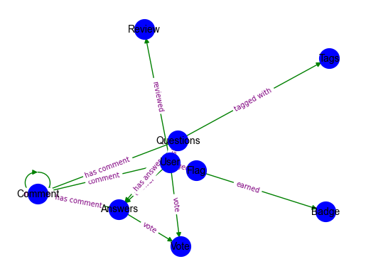

```
User properties: {'properties': ['User_id', 'Display_Name', 'Reputation', 'CreationDate', 'Location']}
Tags properties: {'properties': ['Tag_id', 'Description', 'Name']}
Questions properties: {'properties': ['Question_id', 'Title', 'CreationDate', 'Score', 'Body', 'View_count', 'Accepted_answer_id']}
Answers properties: {'properties': ['Answer_id', 'CreationDate', 'Score', 'Body', 'is_accpeted']}
Comment properties: {'properties': ['Comment_id', 'CreationDate', 'Body', 'Score']}
Badge properties: {'properties': ['Badge_idName', 'CreationDate', 'Description']}
Vote properties: {'properties': ['Vote_type_id', 'CreationDate']}
Review properties: {'properties': ['CreationDate', 'ReviewTaskId', 'Approval_status']}
Flag properties: {}
('User', 'Questions') properties: {'type': 'ask'}
('User', 'Answers') properties: {'type': 'answer'}
('User', 'Comment') properties: {'type': 'comment'}
('User', 'Vote') properties: {'type': 'vote'}
('User', 'Badge') properties: {'type': 'earned'}
('User', 'Review') properties: {'type': 'reviewed'}
('User', 'Flag') properties: {'type': 'flagged'}
('Questions', 'Tags') properties: {'type': 'tagged with'}
('Questions', 'Answers') properties: {'type': 'has answer'}
('Questions', 'Comment') properties: {'type': 'has comment'}
('Answers', 'Vote') properties: {'type': 'vote'}
('Answers', 'Comment') properties: {'type': 'has comment'}
('Comment', 'Comment') properties: {'type': 'reply to'}
('Flag', 'User') properties: {'type': 'flagged_by'}
```

```python
#Add your code for this requirement in this cell
### Use networkx package to create the graph data model of the knowledge graph (Network) for StackOverflow
import networkx as nx
import matplotlib.pyplot as plt

# Empty graph creation
stackoverflow_graph = nx.DiGraph()

# Add nodes
stackoverflow_graph.add_nodes_from(['User', 'Tags', 'Questions', 'Answers', 'Comment', 'Badge', 'Vote', 'Review','Flag'])

# Add edges with properties
stackoverflow_graph.add_edges_from([
    ('User', 'Questions', {'type': 'ask'}),
    ('User', 'Answers', {'type': 'answer'}),
    ('User', 'Comment', {'type': 'comment'}),
    ('User', 'Vote', {'type': 'vote'}),
    ('Questions', 'Tags', {'type': 'tagged with'}),
    ('Questions', 'Answers', {'type': 'has answer'}),
    ('Answers', 'Vote', {'type': 'vote'}),
    ('Questions', 'Comment', {'type': 'has comment'}),
    ('Answers', 'Comment', {'type': 'has comment'}),
    ('Comment', 'Comment', {'type': 'reply to'}),
    ('User', 'Badge', {'type': 'earned'}),
    ('User', 'Review', {'type': 'reviewed'}),
    ('User', 'Flag', {'type': 'flagged'}),
    ('Flag', 'User', {'type': 'flagged_by'})
])


# Define node properties
stackoverflow_graph.nodes['User']['properties'] = ['User_id', 'Display_Name','Reputation', 'CreationDate', 'Location']
stackoverflow_graph.nodes['Tags']['properties'] = ['Tag_id', 'Description','Name']
stackoverflow_graph.nodes['Questions']['properties'] = ['Question_id','Title', 'CreationDate', 'Score','Body', 'View_count','Accepted_answer_id']
stackoverflow_graph.nodes['Answers']['properties'] = ['Answer_id','CreationDate', 'Score','Body','is_accpeted']
stackoverflow_graph.nodes['Comment']['properties'] = ['Comment_id','CreationDate', 'Body','Score']
stackoverflow_graph.nodes['Badge']['properties'] = ['Badge_id''Name', 'CreationDate', 'Description']
stackoverflow_graph.nodes['Vote']['properties'] = ['Vote_type_id', 'CreationDate']
stackoverflow_graph.nodes['Review']['properties'] = ['CreationDate', 'ReviewTaskId','Approval_status']



# Draw the graph
pos = nx.spring_layout(stackoverflow_graph)
nx.draw_networkx_nodes(stackoverflow_graph, pos, node_color='blue', node_size=400)
nx.draw_networkx_edges(stackoverflow_graph, pos, edge_color='green')
edge_labels = nx.get_edge_attributes(stackoverflow_graph, 'type')
nx.draw_networkx_edge_labels(stackoverflow_graph, pos, edge_labels=edge_labels, font_size=7, font_color='purple')
nx.draw_networkx_labels(stackoverflow_graph, pos, font_size=10, font_family='Arial')
plt.axis('off')
plt.show()

# Print node properties
for node in stackoverflow_graph.nodes():
    print(f'{node} properties: {stackoverflow_graph.nodes[node]}')

# Print edge properties
for edge in stackoverflow_graph.edges():
    print(f'{edge} properties: {stackoverflow_graph.edges[edge]}')
```

### Requirement 5:

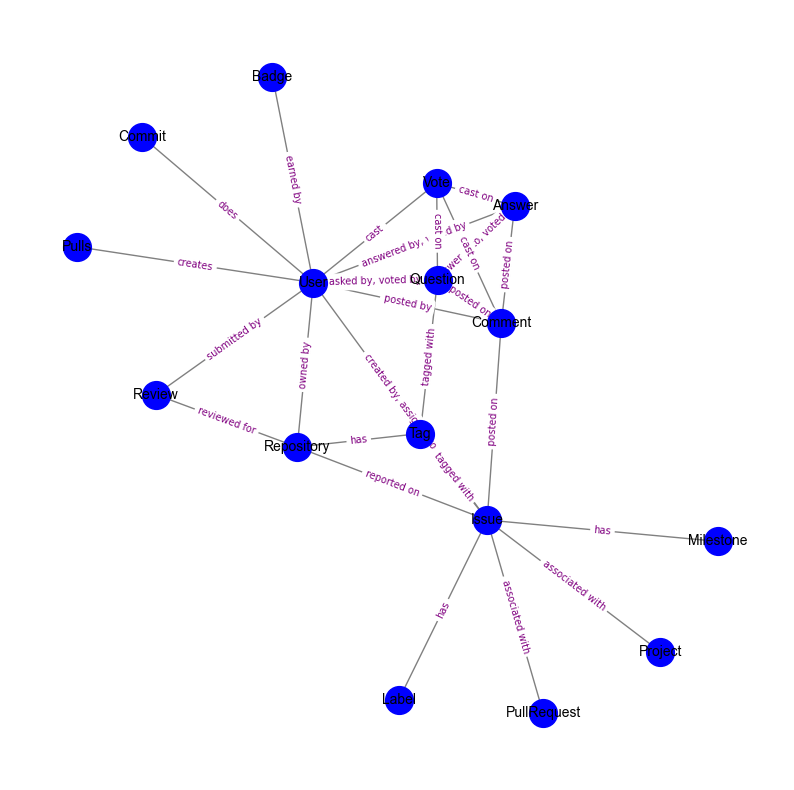

```
('User', 'Repository') properties: {'type': 'owned by'}
('User', 'Issue') properties: {'type': 'created by, assigned to'}
('User', 'Commit') properties: {'type': 'does'}
('User', 'Pulls') properties: {'type': 'creates'}
('User', 'Comment') properties: {'type': 'posted by'}
('User', 'Badge') properties: {'type': 'earned by'}
('User', 'Vote') properties: {'type': 'cast'}
('User', 'Review') properties: {'type': 'submitted by'}
('User', 'Question') properties: {'type': 'asked by, voted by'}
('User', 'Answer') properties: {'type': 'answered by, voted by'}
('Repository', 'Issue') properties: {'type': 'reported on'}
('Repository', 'Tag') properties: {'type': 'has'}
('Repository', 'Review') properties: {'type': 'reviewed for'}
('Issue', 'Comment') properties: {'type': 'posted on'}
('Issue', 'Label') properties: {'type': 'has'}
('Issue', 'Milestone') properties: {'type': 'has'}
('Issue', 'PullRequest') properties: {'type': 'associated with'}
('Issue', 'Project') properties: {'type': 'associated with'}
('Issue', 'Tag') properties: {'type': 'tagged with'}
('Tag', 'Question') properties: {'type': 'tagged with'}
('Question', 'Answer') properties: {'type': 'answered to, voted by'}
('Question', 'Comment') properties: {'type': 'posted on'}
('Question', 'Vote') properties: {'type': 'cast on'}
('Answer', 'Comment') properties: {'type': 'posted on'}
('Answer', 'Vote') properties: {'type': 'cast on'}
('Comment', 'Vote') properties: {'type': 'cast on'}
```

```python
#Add your code for this requirement in this cell
### Use networkx package to create the graph data model of the knowledge graph (Network) for the combined data,
###we will call it the the BugHub knowledge graph, of GitHub and StackOverflow

import networkx as nx
import matplotlib.pyplot as plt

# empty graph creation
BugHub = nx.Graph()

# Adding nodes
nodes = ['User', 'Repository', 'Issue', 'Tag', 'Question', 'Answer', 'Comment', 'Badge', 'Vote', 'Review']
BugHub.add_nodes_from(nodes)

# Adding edges
edges = [('User', 'Repository', {'type': 'own'}),
         ('User', 'Issue', {'type': 'created, assigned to'}),
         ('User', 'Commit', {'type': 'does'}),
         ('User', 'Pulls', {'type': 'creates'}),
         ('User', 'Comment', {'type': 'posted on'}),
         ('User', 'Badge', {'type': 'earned'}),
         ('User', 'Vote', {'type': 'cast'}),
         ('User', 'Review', {'type': 'submitted'}),
         ('User', 'Question', {'type': 'asked, voted'}),
         ('User', 'Answer', {'type': 'answered, voted'}),

         ('Repository', 'Issue', {'type': 'has'}),
         ('Repository', 'Tag', {'type': 'tagged with'}),
         ('Repository', 'User', {'type': 'owned by'}),

         ('Issue', 'Comment', {'type': 'has'}),
         ('Issue', 'Label', {'type': 'has'}),
         ('Issue', 'User', {'type': 'created by, assigned to'}),
         ('Issue', 'Milestone', {'type': 'has'}),
         ('Issue', 'PullRequest', {'type': 'associated with'}),
         ('Issue', 'Project', {'type': 'associated with'}),
         ('Issue', 'Repository', {'type': 'reported on'}),

         ('Tag', 'Repository', {'type': 'has'}),
         ('Tag', 'Issue', {'type': 'tagged with'}),
         ('Tag', 'Question', {'type': 'tagged with'}),

         ('Question', 'Answer', {'type': 'has one or more'}),
         ('Question', 'User', {'type': 'asked by, voted by'}),
         ('Question', 'Tag', {'type': 'tagged with'}),

         ('Answer', 'Question', {'type': 'answered to, voted by'}),
         ('Answer', 'User', {'type': 'answered by, voted by'}),

         ('Comment', 'Issue', {'type': 'posted on'}),
         ('Comment', 'Question', {'type': 'posted on'}),
         ('Comment', 'Answer', {'type': 'posted on'}),
         ('Comment', 'User', {'type': 'posted by'}),

         ('Badge', 'User', {'type': 'earned by'}),

         ('Vote', 'Question', {'type': 'cast on'}),
         ('Vote', 'Answer', {'type': 'cast on'}),
         ('Vote', 'Comment', {'type': 'cast on'}),

         ('Review', 'User', {'type': 'submitted by'}),
         ('Review', 'Repository', {'type': 'reviewed for'})]

BugHub.add_edges_from(edges)

fig, ax = plt.subplots(figsize=(10, 10))
pos = nx.spring_layout(BugHub)
nx.draw_networkx_nodes(BugHub, pos, node_color='blue', node_size=400)
nx.draw_networkx_edges(BugHub, pos, edge_color='gray')
edge_labels = nx.get_edge_attributes(BugHub, 'type')
nx.draw_networkx_edge_labels(BugHub, pos, edge_labels=edge_labels, font_size=7, font_color='purple')
nx.draw_networkx_labels(BugHub, pos, font_size=10, font_family='Arial')
plt.axis('off')
plt.show()

# Print edge properties
for edge in BugHub.edges():
    print(f'{edge} properties: {BugHub.edges[edge]}')
```

### Requirement 6:

```python
### Write Python code (Use the APIs for StackOverflow and GitHub) to retrieve the data for GitHub
### and StackOverflow based on the knowledge graphs you created in Requirements 1, 2, 3, 4, and 5.

import requests

# Set up authentication using a personal access token
token = "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"
headers = {"Authorization": f"Bearer {token}"}

# Define the GitHub API endpoint for retrieving repository information
GITHUB_API_URL = "https://api.github.com/repos/"

# Define the StackOverflow API endpoint for retrieving question information
STACKOVERFLOW_API_URL = "https://api.stackexchange.com/2.3/questions"
stackoverflow_key = "irAprM2zS4dk0AC8TDnGGQ(("
stackoverflow_headers = {"X-API-Key": stackoverflow_key}

# Create a dictionary of repositories and their associated StackOverflow tags
repos = {
    "React": {
        "github": "facebook/react",
        "stackoverflow_tag": "reactjs"
    },
    "Angular": {
        "github": "angular/angular",
        "stackoverflow_tag": "angular"
    },
    "Visualization": {
        "github": "d3/d3",
        "stackoverflow_tag": "d3.js"
    }
}

# Go through the repositories and fetch their details
for repo_name, repo_info in repos.items():

    # Get information about a GitHub repository using the GitHub API
    github_url = GITHUB_API_URL + repo_info["github"]
    github_response = requests.get(github_url, headers=headers)

    if github_response.ok:
        print(f"Retrieved repository information for {repo_name} from GitHub API.")
    else:
        print(f"Failed to retrieve repository information for {repo_name} from GitHub API.")

    github_data = github_response.json()

    # Get the topics associated with a GitHub repository using the GitHub API
    topics_url = github_url + "/topics"
    topics_response = requests.get(topics_url, headers=headers)
    topics_data = topics_response.json()

    # Get the number of issues associated with a repository from the GitHub API
    issues_params = {"state": "open", "type": "issue"}
    issues_url = github_url + "/issues"
    issues_response = requests.get(issues_url, headers=headers, params=issues_params)
    issues_data = issues_response.json()

    open_issues_count = github_data["open_issues_count"]

    # Get the number of tags associated with a repository from the GitHub API,
    # using pagination to retrieve more tags if necessary
    tag_url = github_url + "/tags"
    tag_count = 0
    while tag_url:
        tag_response = requests.get(tag_url, headers=headers)
        tag_data = tag_response.json()
        for tag in tag_data:
            tag_count += 1
        tag_url = tag_response.links.get('next', {}).get('url')

    # Retrieve questions related to the repository from StackOverflow API
    stackoverflow_params = {
        "order": "desc",
        "sort": "votes",
        "tagged": repo_info["stackoverflow_tag"],
        "site": "stackoverflow",
        "pagesize": 25
    }
    stackoverflow_response = requests.get(STACKOVERFLOW_API_URL, headers=stackoverflow_headers, params=stackoverflow_params)
    stackoverflow_data = stackoverflow_response.json()

    print(f"\nRepository: {repo_name}")
    print("\nGitHub Information:")
    print(f"Name: {github_data['name']}")
    print(f"Description: {github_data['description']}")
    print(f"Organization: {github_data['organization']['login']}")
    print(f"Stars: {github_data['stargazers_count']}")
    print(f"Forks: {github_data['forks_count']}")
    print(f"Watchers: {github_data['subscribers_count']}")
    print(f"Issues Count: {open_issues_count}")
    print(f"Tags Count: {tag_count}")
    print()
    if "names" in topics_data:
        topics = topics_data["names"]

        print(f"Topics for {repo_name} repository:")
        for topic in topics:
            print(topic)
    else:
        print("No topics found.")

    print("\nStackOverflow:\n")
    badges_params = {
    "order": "desc",
    "sort": "rank",
    "site": "stackoverflow",
    "filter": "withbody",
    "min": "gold",
    "pagesize": 100,
}

site_params = {
    "site": "stackoverflow"
}

for item in stackoverflow_data["items"]:
    owner_name = item['owner']['display_name']
    question_title = item['title']
    question_tags = item['tags']
    answer_count = item['answer_count']
    print(f"User: {owner_name}")
    print(f"Question: {question_title}")
    print(f"Tags: {question_tags}")
    print(f"Answer Count: {answer_count}")
    print()
    user_badges_url = f"https://api.stackexchange.com/2.3/users/{item['owner']['user_id']}/badges"
    user_badges_response = requests.get(user_badges_url, headers=headers_stackoverflow, params=site_params)
    user_badges_data = user_badges_response.json()

    comments_url = f"https://api.stackexchange.com/2.3/questions/{item['question_id']}/comments"
    comments_response = requests.get(comments_url, headers=headers_stackoverflow, params=site_params)
    comments_data = comments_response.json()

    # Fetching badges for each user
    for badge in user_badges_data['items']:
        badge_name = badge['name']
        print(f"Badges- {badge_name}")

    # Fetching comment ID as comments
    for comment in comments_data['items']:
        if not comment:
            print("No comments found.")
        else:
            comment_id = comment['comment_id']
            print("Comments: ", comment_id)
```

```
Retrieved repository information for React from GitHub API.

Repository: React

GitHub Information:
Name: react
Description: The library for web and native user interfaces
Organization: facebook
Stars: 205995
Forks: 42943
Watchers: 6628
Issues Count: 1242
Tags Count: 141

Topics for React repository:
javascript
react
frontend
declarative
ui
library

StackOverflow:

Retrieved repository information for Angular from GitHub API.

Repository: Angular

GitHub Information:
Name: angular
Description: The modern web developer’s platform
Organization: angular
Stars: 87540
Forks: 23414
Watchers: 3033
Issues Count: 1380
Tags Count: 861

Topics for Angular repository:
angular
```

[output cut: 791 more lines]

```
Answer Count: 2

Badges- Student
Badges- Editor
Badges- Supporter
Badges- Scholar
Badges- Nice Question
Badges- Popular Question
Badges- Commentator
Badges- Tumbleweed
Badges- Curious
Badges- Notable Question
Badges- Good Question
Badges- Yearling
Badges- Famous Question
```

### Requirement 7:

```
Retrieved repository information for React from GitHub API.
Retrieved repository information for Angular from GitHub API.
Retrieved repository information for Visualization from GitHub API.
```

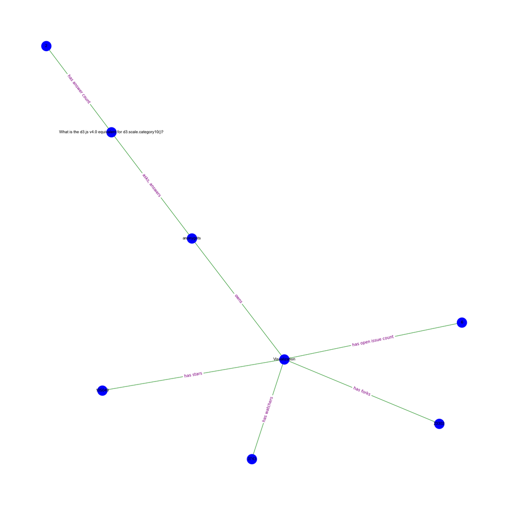

```python
### Use networkx package to create the knowledge graph (Network) for every repo listed in requirement 6.

import networkx as nx
import matplotlib.pyplot as plt
import requests

# Initialize the graph
graph = nx.Graph()

# Set up authentication using a personal access token
token = "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"
headers = {"Authorization": f"Bearer {token}"}

# Define the GitHub API endpoint for retrieving repository information
GITHUB_API_URL = "https://api.github.com/repos/"

# Define the StackOverflow API endpoint for retrieving question information
STACKOVERFLOW_API_URL = "https://api.stackexchange.com/2.3/questions"
stackoverflow_key = "irAprM2zS4dk0AC8TDnGGQ(("
stackoverflow_headers = {"X-API-Key": stackoverflow_key}

# Create a dictionary of repositories and their associated StackOverflow tags
repos = {
    "React": {
        "github": "facebook/react",
        "stackoverflow_tag": "reactjs"
    },
    "Angular": {
        "github": "angular/angular",
        "stackoverflow_tag": "angular"
    },
    "Visualization": {
        "github": "d3/d3",
        "stackoverflow_tag": "d3.js"
    }
}

# Go through the repositories and fetch their details
for repo_name, repo_info in repos.items():

    # Get information about a GitHub repository using the GitHub API
    github_url = GITHUB_API_URL + repo_info["github"]
    github_response = requests.get(github_url, headers=headers)

    if github_response.ok:
        print(f"Retrieved repository information for {repo_name} from GitHub API.")
    else:
        print(f"Failed to retrieve repository information for {repo_name} from GitHub API.")

    github_data = github_response.json()

    # Get the topics associated with a GitHub repository using the GitHub API
    topics_url = github_url + "/topics"
    topics_response = requests.get(topics_url, headers=headers)
    topics_data = topics_response.json()

    # Get the number of issues associated with a repository from the GitHub API
    issues_params = {"state": "open", "type": "issue"}
    issues_url = github_url + "/issues"
    issues_response = requests.get(issues_url, headers=headers, params=issues_params)
    issues_data = issues_response.json()

    open_issues_count = github_data["open_issues_count"]
    stars = github_data['stargazers_count']
    forks = github_data['forks_count']
    watchers = github_data['subscribers_count']

    # Get the number of tags associated with a repository from the GitHub API,
    # using pagination to retrieve more tags if necessary
    tag_url = github_url + "/tags"
    tag_count = 0
    while tag_url:
        tag_response = requests.get(tag_url, headers=headers)
        tag_data = tag_response.json()
        for tag in tag_data:
            tag_count += 1
        tag_url = tag_response.links.get('next', {}).get('url')
    graph = nx.Graph()
    # Add the github node to the graph
    graph.add_node(repo_name, properties="repository")
    graph.add_node(open_issues_count, properties="issues")
    graph.add_node(stars, properties="stars")
    graph.add_node(forks, properties="forks")
    graph.add_node(watchers, properties="watchers")


    # Create an edge between the nodes
    graph.add_edge(repo_name, open_issues_count, type="has open issue count")
    graph.add_edge(repo_name, stars, type="has stars")
    graph.add_edge(repo_name, forks, type="has forks")
    graph.add_edge(repo_name, watchers, type="has watchers")


    # Retrieve questions related to the repository from StackOverflow API
    stackoverflow_params = {
        "order": "desc",
        "sort": "votes",
        "tagged": repo_info["stackoverflow_tag"],
        "site": "stackoverflow",
        "pagesize": 25
    }
    stackoverflow_response = requests.get(STACKOVERFLOW_API_URL, headers=stackoverflow_headers, params=stackoverflow_params)
    stackoverflow_data = stackoverflow_response.json()

    for item in stackoverflow_data["items"]:
        user = item['owner']['display_name']
        question = item['title']
        tags = item['tags']
        answer_count = item['answer_count']

    #Add the github node to the graph
    graph.add_node(user, properties="user")
    graph.add_node(question, properties="question")
    graph.add_node(answer_count, properties="answer count")


    # Create an edge between the nodes
    graph.add_edge(repo_name, user, type="owns")
    graph.add_edge(user, question, type="asks, answers")
    graph.add_edge(question, answer_count, type="has answer count")


#Draw the graph
fig, ax = plt.subplots(figsize=(25, 25))
pos = nx.spring_layout(graph)
nx.draw_networkx_nodes(graph, pos, node_color = 'blue', node_size = 750)
nx.draw_networkx_edges(graph, pos, edge_color = 'green')
edge_labels = nx.get_edge_attributes(graph, 'type')
nx.draw_networkx_edge_labels(graph, pos, edge_labels=edge_labels, font_size = 11, font_color = 'purple')
nx.draw_networkx_labels(graph, pos, font_size = 11, font_family = 'Arial')
plt.axis('off')
plt.show()
```

### Requirement 8:

```python
#Add your code for this requirement in this cell

### Go to GitHub and StackOverflow and inspect the following topics, repos,
###and tags and document the most relevant repos and tags for every topic:

Here are the most relevant repositories and tags for the given topics on GitHub and StackOverflow:

a. React

Relevant Github repositories:
    i. https://github.com/facebook/react- The main React repository maintained by Facebook.
    ii. https://github.com/reduxjs/redux - A predictable state container for JavaScript apps.
    iii. https://github.com/reactjs/react-redux - A library for managing state in React applications.
    iv. https://github.com/FormidableLabs/react-live - A playground for live editing React code.
    v. https://github.com/styled-components/styled-components - A library for styling React components with CSS.


Relevant tags on StackOverflow: reactjs, react-native, react-router,
                                react-hooks,react-redux, react-router-dom,
                                react-query


b. Angular

Relevant Github repositories:
    i. https://github.com/angular/angular- The main Angular repository maintained by the Angular team.
    ii.  https://github.com/angular/angular-cli - A command-line interface for creating and managing Angular projects.
    iii. https://github.com/ng-bootstrap/ng-bootstrap - A set of Angular components based on Bootstrap 5.
    iv. https://github.com/ngx-translate/core - A library for internationalization (i18n) in Angular applications.
    v. https://github.com/ngrx/platform - A reactive state management library for Angular applications.

Relevant tags on StackOverflow: angular, angularjs, angular-material, angular-routing,
                                angular-directive, angular-forms, angular-testing,
                                angular-component

c. Visualization

Relevant Github repositories:
    i. https://github.com/d3/d3- A library for creating data visualizations using JavaScript and SVG.
    ii. https://github.com/vega/vega - A visualization grammar and framework for creating interactive visualizations.
    iii. https://github.com/vega/vega-lite - A high-level grammar for creating visualizations using D3
         and other libraries.
    iv. https://github.com/presalytics/storyteller - A Python library for creating interactive data visualizations.
    v. https://github.com/airbnb/visx - A library for creating custom visualizations with D3 and React.
    vi. https://github.com/plotly/plotly.js - A library for creating interactive, web-based plots and charts.

Relevant tags on StackOverflow: d3.js, data-visualization, d3-force, chart.js, matplotlib, highcharts, seaborn, bokeh
```

### Requirement 9:

```python
### Use GitHub API to retrieve information of the past 2 years for the following repositories:
1.https://github.com/angular/angular
2.https://github.com/angular/material
3.https://github.com/angular/angular-cli
4.https://github.com/SebastianM/angular-google?maps
5.https://github.com/d3/d3
6.https://github.com/facebook/react
7.https://github.com/tensorflow/tensorflow
8.https://github.com/keras-team/keras
9.https://github.com/pallets/flask
```

```python
#install PyGihub using below command in your terminal also install in jupyter if it doesn't work
#sudo pip3 install PyGithub
#!pip install PyGithub
```

```python
from datetime import datetime, timedelta
from github import Github

# GitHub API authentication token
TOKEN = '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'

# Create a Github instance using PyGithub library
github_client = Github(TOKEN)

# List of repository names
repositories = [
    'angular/angular',
    'angular/material',
    'angular/angular-cli',
    'SebastianM/angular-google-maps',
    'd3/d3',
    'facebook/react',
    'tensorflow/tensorflow',
    'keras-team/keras',
    'pallets/flask'
]

# Date range for filtering data
today = datetime.today()
two_years_ago = today - timedelta(days=730) #365 * 2

# Retrieve information for each repository
for repo_name in repositories:
    repo = github_client.get_repo(repo_name)
    print(f"Repository Name: {repo.name}")
    print(f"Description: {repo.description}")
    print(f"Number of Stars: {repo.stargazers_count}")
    print(f"Number of Forks: {repo.forks_count}")
    print(f"Number of Watchers: {repo.watchers_count}")
    print(f"Number of Open Issues: {repo.open_issues_count}")
    print(f"Last Updated On: {repo.updated_at}")

    # Retrieve commits within the past 2 years
    commits = repo.get_commits(since=two_years_ago)
    print(f"Number of Commits (past 2 years): {commits.totalCount}")
    print('\n')
```

```
Repository Name: angular
Description: The modern web developer’s platform
Number of Stars: 87540
Number of Forks: 23414
Number of Watchers: 87540
Number of Open Issues: 1380
Last Updated On: 2023-04-18 19:50:06
Number of Commits (past 2 years): 5409


Repository Name: material
Description: Material design for AngularJS
Number of Stars: 16685
Number of Forks: 3514
Number of Watchers: 16685
Number of Open Issues: 278
Last Updated On: 2023-04-18 07:41:10
Number of Commits (past 2 years): 19


Repository Name: angular-cli
Description: CLI tool for Angular
Number of Stars: 26050
Number of Forks: 12101
Number of Watchers: 26050
Number of Open Issues: 219
Last Updated On: 2023-04-19 01:32:29
Number of Commits (past 2 years): 2605


Repository Name: angular-google-maps
Description: Angular 2+ Google Maps Components
Number of Stars: 2006
Number of Forks: 789
Number of Watchers: 2006
Number of Open Issues: 49
Last Updated On: 2023-04-12 06:06:13
Number of Commits (past 2 years): 2


```

[output cut: 33 more lines]

```
Number of Forks: 19322
Number of Watchers: 57945
Number of Open Issues: 408
Last Updated On: 2023-04-19 00:02:40
Number of Commits (past 2 years): 2594


Repository Name: flask
Description: The Python micro framework for building web applications.
Number of Stars: 62615
Number of Forks: 15578
Number of Watchers: 62615
Number of Open Issues: 0
Last Updated On: 2023-04-19 01:23:38
Number of Commits (past 2 years): 807
```

### Requirement 10:

```python
#Add your code for this requirement in this cell

### Use StackOverflow API to retrieve information of the past 2 years for Tags related to the repositories
### listed in requirement 9.
```

```python
import requests
import time

# Define the repositories and their associated tags
repos_tags = [
    ("angular/angular", "angular"),
    ("angular/material", "angular-material"),
    ("angular/angular-cli", "angular-cli"),
    ("SebastianM/angular-google-maps", "angular-google-maps"),
    ("d3/d3", "d3.js"),
    ("facebook/react", "reactjs"),
    ("tensorflow/tensorflow", "tensorflow"),
    ("keras-team/keras", "keras"),
    ("pallets/flask", "flask")
]

# Define the API endpoint and key
api_endpoint = "https://api.stackexchange.com/2.3/questions"
api_key = "irAprM2zS4dk0AC8TDnGGQ(("

# Date range for filtering data
today = datetime.today()
two_years_ago = today - timedelta(days=730) #365 * 2

# Set the date range for the query
date_string = two_years_ago.strftime("%Y-%m-%d")
unix_timestamp = int(time.mktime(time.strptime(date_string, "%Y-%m-%d")))


# Define the query parameters
params = {
    "fromdate": unix_timestamp,
    "order": "desc",
    "sort": "votes",
    "site": "stackoverflow",
    "pagesize": 1,
    "key": api_key
}

# Loop through the repositories and retrieve information on their associated tags
for repo, tag in repos_tags:
    # Define the query parameters
    params["tagged"] = tag

    # Make the API request
    response = requests.get(f"{api_endpoint}", params=params)

    # Parse the response
    data = response.json()

    #Print the most popular question related to the repository and tag
    print(f"\nMost popular question for {repo} with tag '{tag}':")
    print(f"Title: {data['items'][0]['title']}")
    print(f"Tags: {data['items'][0]['tags']}")
    print(f"Link: {data['items'][0]['link']}")
    print(f"Creation Date: {datetime.fromtimestamp(data['items'][0]['creation_date'])}")
    print(f"Last Activity Date: {datetime.fromtimestamp(data['items'][0]['last_activity_date'])}")


    print("\n")
    #uncomment this line to print the whole data
    #print(data)
```

```
Most popular question for angular/angular with tag 'angular':
Title: unable to resolve dependency tree error for creating new angular project
Tags: ['angular', 'npm']
Link: https://stackoverflow.com/questions/67433893/unable-to-resolve-dependency-tree-error-for-creating-new-angular-project
Creation Date: 2021-05-07 06:11:49
Last Activity Date: 2022-06-14 12:22:37



Most popular question for angular/material with tag 'angular-material':
Title: Property &#39;fName&#39; comes from an index signature, so it must be accessed with [&#39;fName&#39;]
Tags: ['angular', 'angular-material', 'components']
Link: https://stackoverflow.com/questions/70106472/property-fname-comes-from-an-index-signature-so-it-must-be-accessed-with-fn
Creation Date: 2021-11-25 00:04:40
Last Activity Date: 2023-03-11 09:32:34



Most popular question for angular/angular-cli with tag 'angular-cli':
Title: ng build --prod =&gt; Error: Unknown argument: prod
Tags: ['angular', 'angular-cli']
Link: https://stackoverflow.com/questions/73156911/ng-build-prod-error-unknown-argument-prod
Creation Date: 2022-07-28 12:24:48
Last Activity Date: 2023-04-05 02:32:39



Most popular question for SebastianM/angular-google-maps with tag 'angular-google-maps':
Title: Getting google.maps.Map instance from @angular/google-maps
Tags: ['angular', 'angular-cdk', 'angular-google-maps']
Link: https://stackoverflow.com/questions/69478083/getting-google-maps-map-instance-from-angular-google-maps
Creation Date: 2021-10-07 03:44:54
Last Activity Date: 2022-08-31 03:54:00



Most popular question for d3/d3 with tag 'd3.js':
Title: How do I resolve &quot;[ERR_REQUIRE_ESM]: Must use import to load ES Module&quot; when using D3.js 7.0.0 with Next.js 11.0.1?
Tags: ['javascript', 'node.js', 'd3.js', 'next.js', 'node-modules']
Link: https://stackoverflow.com/questions/68126052/how-do-i-resolve-err-require-esm-must-use-import-to-load-es-module-when-usi
```

[output cut: 23 more lines]

```
Most popular question for keras-team/keras with tag 'keras':
Title: Keras AttributeError: &#39;Sequential&#39; object has no attribute &#39;predict_classes&#39;
Tags: ['python', 'keras']
Link: https://stackoverflow.com/questions/68836551/keras-attributeerror-sequential-object-has-no-attribute-predict-classes
Creation Date: 2021-08-18 12:01:31
Last Activity Date: 2023-02-21 07:22:51



Most popular question for pallets/flask with tag 'flask':
Title: Import could not be resolved/could not be resolved from source Pylance in VS Code using Python 3.9.2 on Windows 10
Tags: ['python', 'flask', 'visual-studio-code', 'pylance']
Link: https://stackoverflow.com/questions/68486207/import-could-not-be-resolved-could-not-be-resolved-from-source-pylance-in-vs-cod
Creation Date: 2021-07-22 09:02:27
Last Activity Date: 2023-03-12 17:04:20
```

### Requirement 11:

```python
#Add your code for this requirement in this cell
### Store your GitHub data in a DataFrame
### and retrieve from the DataFrame the repo that has the highest number of GitHub issues created.

from datetime import datetime, timedelta
from github import Github
import pandas as pd

#GitHub API authentication token
TOKEN = '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'

#Instantiate Github object
gh = Github(TOKEN)

#List of repositories to retrieve data for
repositories = [
'angular/angular',
'angular/material',
'angular/angular-cli',
'SebastianM/angular-google-maps',
'd3/d3',
'facebook/react',
'tensorflow/tensorflow',
'keras-team/keras',
'pallets/flask'
]

#Date range for filtering data
today = datetime.today()
two_years_ago = today - timedelta(days=730) #365 * 2

#Collect data about each repository and store it in a DataFrame
repo_data = []
for repository in repositories:
    repo = gh.get_repo(repository)
    repo_dict = {
    'Name': repo.name,
    'Description': repo.description,
    'Stars': repo.stargazers_count,
    'Forks': repo.forks_count,
    'Watchers': repo.watchers_count,
    'Open Issues': repo.open_issues_count,
    'Last Updated': repo.updated_at,
    'Number of Commits (past 2 years)': repo.get_commits(since=two_years_ago).totalCount
    }
    repo_data.append(repo_dict)
    df = pd.DataFrame(repo_data)

#Change the data type of the 'Open Issues' column from string to integer
df['Open Issues'] = df['Open Issues'].astype(int)

#Find the repository with the highest number of open issues
max_open_issues_repo = df.loc[df['Open Issues'].idxmax(), 'Name']
print(f"The repository with the highest number of open issues is {max_open_issues_repo}.")
```

```
The repository with the highest number of open issues is tensorflow.
```

### Requirement 12:

```python
#Add your code for this requirement in this cell
### Store your StackOverflow data in a DataFrame and retrieve
###from the DataFrame the repo/tag that has the highest number of StackOverflow questions created.


import pandas as pd
import requests
import time
import warnings
warnings.filterwarnings('ignore')

# Define the repositories and their associated tags
repositories = [
    ("angular/angular", "angular"),
    ("angular/material", "angular-material"),
    ("angular/angular-cli", "angular-cli"),
    ("SebastianM/angular-google-maps", "angular-google-maps"),
    ("d3/d3", "d3.js"),
    ("facebook/react", "reactjs"),
    ("tensorflow/tensorflow", "tensorflow"),
    ("keras-team/keras", "keras"),
    ("pallets/flask", "flask")
]

# Define the StackOverflow API endpoint and key
api_url = "https://api.stackexchange.com/2.3/questions"
api_key = "irAprM2zS4dk0AC8TDnGGQ(("

# Define the query parameters
params = {
    "order": "desc",
    "sort": "votes",
    "site": "stackoverflow",
    "pagesize": 1,
    "key": api_key
}

# Create an empty DataFrame to store the data
df = pd.DataFrame(columns=["Repository", "Tag", "Questions"])

# Loop through the repositories and retrieve information on their associated tags
for repository, tag in repositories:
    # Define the query parameters
    params["tagged"] = tag

    # Date range for filtering data
    today = datetime.today()
    two_years_ago = today - timedelta(days=730) #365 * 2

    # Set the date range for the query
    date_string = two_years_ago.strftime("%Y-%m-%d")
    unix_timestamp = int(time.mktime(time.strptime(date_string, "%Y-%m-%d")))
    params["fromdate"] = unix_timestamp

    # Make the API request
    response = requests.get(api_url, params=params)

    # Parse the response
    data = response.json()

    # Extract the number of questions
    num_questions = data["items"][0]["question_id"]

    # Add the data to the DataFrame
    df = df.append({"Repository": repository, "Tag": tag, "Questions": num_questions}, ignore_index=True)

# Change the data type of the 'Questions' column from string to integer
df["Questions"] = df["Questions"].astype(int)

# Get the row with the highest number of questions
max_questions_row = df.loc[df["Questions"].idxmax()]

# Print the repository/tag with the highest number of questions
print(f"The repository/tag with the highest number of questions is {max_questions_row['Repository']}/{max_questions_row['Tag']} with {max_questions_row['Questions']} questions.")
```

```
The repository/tag with the highest number of questions is angular/angular-cli/angular-cli with 73156911 questions.
```

### Requirement 13:

```python
#Add your code for this requirement in this cell

### Store your StackOverflow data in a DataFrame and retrieve from the DataFrame the top 5 questions
###for React on StackOverflow that have the highest number of answers, votes, and views.

import pandas as pd
from requests import get

# Define the API endpoint and key
api_url = "https://api.stackexchange.com/2.3/questions"
api_key = "irAprM2zS4dk0AC8TDnGGQ(("

# Define the query parameters
params = {
    "order": "desc",
    "sort": "votes",
    "site": "stackoverflow",
    "pagesize": 5,
    "key": api_key,
    "tagged": "reactjs"
}

# Make the API request and store the response
response = get(api_url, params=params)

# Extract relevant data from the response and create a pandas DataFrame
data = response.json()["items"]
df = pd.DataFrame(data, columns=["question_id", "title", "answer_count", "score", "view_count"])

# Print the top 5 questions with highest number of answers
print("\nTop 5 questions with highest number of answers:")
print(df.sort_values(by="answer_count", ascending=False).head())

# Print the top 5 questions with highest number of votes
print("\nTop 5 questions with highest number of votes:")
print(df.sort_values(by="score", ascending=False).head())

# Print the top 5 questions with highest number of views
print("\nTop 5 questions with highest number of views:")
print(df.sort_values(by="view_count", ascending=False).head())
```

```
Top 5 questions with highest number of answers:
   question_id                                              title  \
1     22876978                              Loop inside React JSX
4     69692842  Error message &amp;quot;error:0308010C:digital...
0     31079081       Programmatically navigate using React router
3     32370994         How to pass props to {this.props.children}
2     31048953          What are these three dots in React doing?

   answer_count  score  view_count
1            84   1919     1766851
4            51   1340     1464858
0            43   2201     1487943
3            32   1393      876552
2            23   1430      614571

Top 5 questions with highest number of votes:
   question_id                                              title  \
0     31079081       Programmatically navigate using React router
1     22876978                              Loop inside React JSX
2     31048953          What are these three dots in React doing?
3     32370994         How to pass props to {this.props.children}
4     69692842  Error message &amp;quot;error:0308010C:digital...

   answer_count  score  view_count
0            43   2201     1487943
1            84   1919     1766851
2            23   1430      614571
3            32   1393      876552
4            51   1340     1464858

Top 5 questions with highest number of views:
   question_id                                              title  \
1     22876978                              Loop inside React JSX
0     31079081       Programmatically navigate using React router
4     69692842  Error message &amp;quot;error:0308010C:digital...
3     32370994         How to pass props to {this.props.children}
2     31048953          What are these three dots in React doing?

   answer_count  score  view_count
1            84   1919     1766851
0            43   2201     1487943
4            51   1340     1464858
3            32   1393      876552
2            23   1430      614571
```